# NPDE Project 3

## Solve invisicd Burger's equation and linear advection equation with following schemes under different initial conditions.

*B02502089 Yuan Yu-Yuan*

*2018/06/04*

## Import Necessary Libraries

```python
import matplotlib.pyplot as plt
from matplotlib import animation
from IPython.display import HTML
import numpy as np
np.seterr(all="ignore")

plt.rcParams['figure.figsize'] = [15, 8]
```

## Domain and Initial Condition

Domain is $[-L, L], L=5$, and two cases of the initial condition.

- Case 1, square wave:

$$u(x,0)=\begin{cases} 1, & \text{if}\ 0 \leq x \leq 1 \\ 0, & \text{otherwise} \end{cases}$$

- Case 2, sine wave:

$$u(x,0)=sin(\pi x)\text{, with periodic boundary condition.}$$

## The CFL Condition

For the sake of stablility, the schemes must satisty the Courant-Friedrichs-Lewy condition,

$$\left| a(u) \frac{\Delta t}{\Delta x} \right| \leq 1 $$

where $a(u)=\frac{\partial f}{\partial u}$ is the wave speed.

```python
global dx
global dt
dx = 1e-2
cfl = 0.6
dt = cfl * dx
time = np.arange(0, 3, dt, dtype='float64')
space = np.arange(-5, 5, dx, dtype='float64')
u0 = {'Square Wave': lambda x: ((x >= 0) & (x <= 1)) * 1.0,
      'Sine Wave': lambda x: np.sin(np.pi * x)}
```

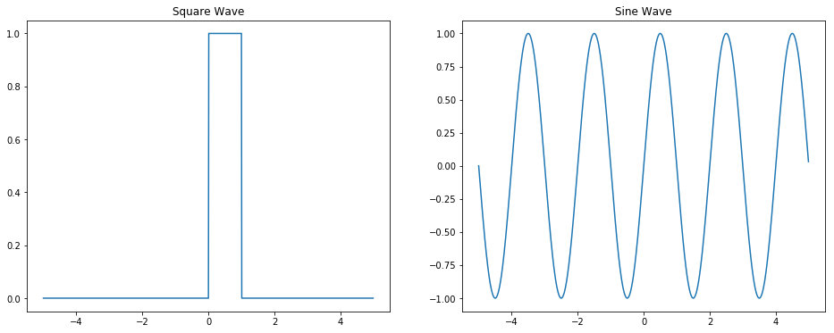

```python
fig = plt.gcf()
fig.set_size_inches(16, 6)
for i, case in enumerate(u0):
    plt.subplot(1, 2, i+1)
    plt.plot(space, u0[case](space))
    plt.title(case)
plt.show()
```

## Conservative Finite Difference Schemes

We can write the schemes for solving the conservation law equation

$$u_t + f(u)_x = 0$$

in the explicit form

$$u^{n+1}_j=u^{n}_j-\frac{\Delta t}{\Delta x}(h^{n}_{j+1/2}-h^{n}_{j-1/2})$$

where $h$ is a consistent numerical flux function of $u^{n}_j$, $u^{n}_{j+1}$, ...

$ u^{n}_j=u(j\Delta x, n\Delta t) $, $\Delta x, \Delta t$ are the partition of space and time respectively.

> For the convenience, $u_j$ represnts $u$ in a certain time, so the iterative formula becomes $$u_{j+1}=u_j-\frac{\Delta t}{\Delta x}(h_{j+1/2}-h_{j-1/2})$$, and use captial letters to represent vectors, such as $U=(u_j)$

```python
def update(U, H):
    return U - dt/dx*(H - np.roll(H, 1))
```

And for **inviscid Burger's equation** and **linear advection equation**, $f(u)=\frac{u^2}{2}$ and $au$ respectively.

```python
a = 1
f = {'Inviscid Burger': lambda u: (np.power(u, 2))/2,
     'Linear Advection': lambda u: a*u}
df = {'Inviscid Burger': lambda u: u,
      'Linear Advection': lambda u: a*np.ones(u.shape, dtype='float64')}
```

## Spreading Speed of Information

For some schemes, we need to ensure the stencil of the sceme won't excceed the stability region.

Thus, we need to compute the spreading speed of the information(slope of the schematic stencil).

$$v_{j+1/2}=\begin{cases} \frac{\Delta t}{\Delta x} \frac{f_{j+1}-f_{j}}{u_{j+1}-u_{j}}, & u_{j} \neq u_{j+1} \\ \frac{\Delta t}{\Delta x} f'(u_j), & u_{j} = u_{j+1} \end{cases}$$

$$v_{j-1/2}=\begin{cases} \frac{\Delta t}{\Delta x} \frac{f_{j}-f_{j-1}}{u_{j}-u_{j-1}}, & u_{j} \neq u_{j-1} \\ \frac{\Delta t}{\Delta x} f'(u_{j-1}), & u_{j} = u_{j-1} \end{cases}$$

```python
def spreading_speed(U, F, dF):
    V = np.zeros(U.shape, dtype='float64')
    delta_F = np.roll(F, -1)-F
    delta_U = np.roll(U, -1)-U

    idx = np.where(delta_U != 0)
    V[idx] = delta_F[idx]/delta_U[idx]

    idx = np.where(delta_U == 0)
    V[idx] = dF[idx]
    return dt/dx * dF
```

## Scheme: Lax-Friedrichs

The numerical flux is given by

$$h_{j+1/2}=\frac{1}{2}(f_{j+1}+f_{j})-\frac{\Delta x}{2 \Delta t}(u_{j+1}-u_{j})$$

$$h_{j-1/2}=\frac{1}{2}(f_{j}+f_{j-1})-\frac{\Delta x}{2 \Delta t}(u_{j}-u_{j-1})$$

```python
def Lax_Friedrichs(U, fcn):
    f, df = fcn
    F = f(U)
    mean_F = (np.roll(F, -1)+F)/2
    delta_U = np.roll(U, -1)-U
    return mean_F - dx/dt * delta_U/2
```

## Scheme: Upwind

For the sake of stability, we should consider the spread speeed to determine the direction of the upwind method applied.

$$h_{j+1/2}=\begin{cases} f_j, & v_{j+1/2} > 0 \\ f_{j+1}, & v_{j+1/2} < 0 \end{cases}$$

and for $h_{j-1/2}$, we do the similar way,

$$h_{j-1/2}=\begin{cases} f_{j-1}, & v_{j-1/2} > 0 \\ f_{j}, & v_{j-1/2} < 0 \end{cases}$$

```python
def upwind(U, fcn):
    f, df = fcn
    F = f(U)
    V = spreading_speed(U, F, df(U))
    return np.roll(F, -1)*(V < 0) + F*(V > 0)
```

## Scheme: Lax-Wendroff

The numerical flux is given by

$$h_{j+1/2}=f(\frac{u_{j+1}+u_{j}}{2}-\frac{\Delta t}{2 \Delta x}(f_{j+1}-f_{j}))$$

$$h_{j-1/2}=f(\frac{u_{j}+u_{j-1}}{2}-\frac{\Delta t}{2 \Delta x}(f_{j}-f_{j-1}))$$

```python
def Lax_Wendroff(U, fcn):
    f, df = fcn
    F = f(U)
    mean_U = (np.roll(U, -1)+U)/2
    delta_F = np.roll(F, -1)-F
    return f(mean_U - dt/dx*delta_F/2)
```

## Scheme: Beam-Warming

Like the upwind scheme, we need to notice the spread direction of the wave.

The numerical flux is given by

$$h_{j+1/2}=\begin{cases} \frac{1}{2} (3f_{j} - f_{j-1})-\frac{1}{2}v_{j-1/2}(f_{j}-f_{j-1}), & v_{j+1/2} > 0 \\ \frac{1}{2} (3f_{j+1} - f_{j+2})-\frac{1}{2}v_{j+3/2}(f_{j+2}-f_{j+1}), & v_{j+1/2} < 0 \end{cases}$$

$$h_{j-1/2}=\begin{cases} \frac{1}{2} (3f_{j-1} - f_{j-2})-\frac{1}{2}v_{j-3/2}(f_{j-1}-f_{j-2}), & v_{j-1/2} > 0 \\ \frac{1}{2} (3f_{j} - f_{j+1})-\frac{1}{2}v_{j+1/2}(f_{j+1}-f_{j}), & v_{j-1/2} < 0 \end{cases}$$

```python
def Beam_Warming(U, fcn):
    f, df = fcn
    F = f(U)
    V = spreading_speed(U, F, df(U))
    delta_F = F-np.roll(F, 1)
    greater_1 = 1/2*(3*F-np.roll(F, 1))
    greater_2 = 1/2*(-np.roll(V, 1)*delta_F)
    greater = greater_1 + greater_2
    less_1 = np.roll(greater_1, -1)
    less_2 = np.roll(greater_2, -2)
    less = less_1 + less_2
    return greater * (V > 0) + less * (V < 0)
```

### Collect all schemes

```python
scheme = {'Lax Friedrichs': Lax_Friedrichs,
          'Upwind': upwind,
          'Lax Wendroff': Lax_Wendroff,
          'Beam Warming': Beam_Warming}
```

## Compute and store all the simulations

```python
history_all = []
for eq in f:
    history = {}
    for case in u0:
        history[case] = {}
        for scheme_name in scheme:
            U = u0[case](space)
            history[case][scheme_name] = [U]
            for i in range(len(time)):
                fcn = (f[eq], df[eq])
                U = update(U, scheme[scheme_name](U, fcn))
                history[case][scheme_name].append(U)
    history_all.append(history)
```

## animation function

```python
def animate(i):
    frame = []
    for case in u0:
        for scheme_name in scheme:
            data = history[case][scheme_name][i]
            _line = line[case][scheme_name]
            _line.set_data(space, data)
            frame.append(_line)
    return frame
```

## Initialize the plots

```python
fig, axes = plt.subplots(2, 4)
line = {}
set_scheme_title = 0
for case, case_ax in zip(history, axes):
    line[case] = {}
    set_case_title = False
    for scheme_name, ax in zip(history[case], case_ax):
        ax.set_xlim(space[0], space[-1])
        ax.set_ylim(-2, 2)
        if set_scheme_title < 4:
            ax.set_title(scheme_name)
            set_scheme_title = set_scheme_title + 1
        if not set_case_title:
            ax.set_ylabel(case)
            set_case_title = True
        line[case][scheme_name], = ax.plot([], [], lw=0.5)
```

## Plot the case of Inviscid Burger's Equation

```python
history = history_all[0]
anim = animation.FuncAnimation(fig, func=animate, frames=len(time),
                               interval=10, blit=True)
HTML(anim.to_html5_video())
```

[video not shown]

## Discussion

In conclusion, the Lax-Friedrcihs scheme works great, either on square wave or sine wave.

The upwind scheme works well on the square wave but has abnormal tail on the sine wave.

And in the case of Lax-Wendroff scheme, there are some noises occur in the both diagram.

Note that the noise would not decrease in the case of square wave.

Beam-Warming scheme improves the problem of the upwind in the case of sine wave.

## Plot the case of Linear Advection Equation

```python
history = history_all[1]
anim = animation.FuncAnimation(fig, func=animate, frames=len(time),
                               interval=10, blit=True)
HTML(anim.to_html5_video())
```

[video not shown]

## Discussion

For sine waves, all of the schemes work well.

But there are some noises in the case of square wave while appyling Lax-Wendroff and Beam-Warming schemes.